# Reproducible Research

Project1  
11/14/2015  
mdavis3419

We are going to be examining what the walking pattern of an individual was over the course of October and November in 2012. We have data in 5 minute intervals recording the number of steps taken durring that period of time.

In order to work with this data we can move to the folder we want to work in.

```
setwd("<your desired directory>")
```

### Loading and preprocessing the data

We can then retrieve the data by downloading, unziping, and loading the data from [my fork](https://github.com/mdavis3419/RepData_PeerAssessment1) of the [master GitHub repository](https://github.com/rdpeng/RepData_PeerAssessment1) using the following function.

```r
getdata <- function(){
  temp <- tempfile()
  url <- "https://github.com/mdavis3419/RepData_PeerAssessment1/blob/master/activity.zip?raw=true"
  download.file(url, temp, mode="wb")
  unzip(temp, "activity.csv")
  read.table("activity.csv", sep=",", header=T)
  }
```

And we can assign the data to the variable CompleteActivityLog so that we can continue to work with the full dataset.

```r
  CompleteActivityLog <- getdata()
```

If we take a look at the first few rows of the data we can see that there are null values in the form of “NA”, and that we have 3 fields “steps”, “date”, and “interval”.

```r
  head(CompleteActivityLog)
```

```
##   steps       date interval
## 1    NA 2012-10-01        0
## 2    NA 2012-10-01        5
## 3    NA 2012-10-01       10
## 4    NA 2012-10-01       15
## 5    NA 2012-10-01       20
## 6    NA 2012-10-01       25
```

There are two things we should do before we get started. First We are going to find out what the data types of each of the fields are.

```r
  sapply(CompleteActivityLog, class)
```

```
##     steps      date  interval
## "integer"  "factor" "integer"
```

And next we are going to create a second dataset, which we will call nonNullActivityLog. Which only contains the values of the activity log that have non-null values in the steps column.

```r
  nonNullActivityLog <- CompleteActivityLog[!is.na(CompleteActivityLog),]
```

Now that we have all of our basic information, let’s look at the first problem to solve.

### What is mean total number of steps taken per day?

We are going to use the non-null dataset for this analysis so that we can get an understanding of the data we have records for.

We are going to approach this problem in a few steps.

First we are going to find the total number of steps per day.

```r
  stepsPerDay <- tapply(nonNullActivityLog$steps, nonNullActivityLog$date, sum)
  stepsPerDay
```

```
## 2012-10-01 2012-10-02 2012-10-03 2012-10-04 2012-10-05 2012-10-06
##         NA        126      11352      12116      13294      15420
## 2012-10-07 2012-10-08 2012-10-09 2012-10-10 2012-10-11 2012-10-12
##      11015         NA      12811       9900      10304      17382
## 2012-10-13 2012-10-14 2012-10-15 2012-10-16 2012-10-17 2012-10-18
##      12426      15098      10139      15084      13452      10056
## 2012-10-19 2012-10-20 2012-10-21 2012-10-22 2012-10-23 2012-10-24
##      11829      10395       8821      13460       8918       8355
## 2012-10-25 2012-10-26 2012-10-27 2012-10-28 2012-10-29 2012-10-30
##       2492       6778      10119      11458       5018       9819
## 2012-10-31 2012-11-01 2012-11-02 2012-11-03 2012-11-04 2012-11-05
##      15414         NA      10600      10571         NA      10439
## 2012-11-06 2012-11-07 2012-11-08 2012-11-09 2012-11-10 2012-11-11
##       8334      12883       3219         NA         NA      12608
## 2012-11-12 2012-11-13 2012-11-14 2012-11-15 2012-11-16 2012-11-17
##      10765       7336         NA         41       5441      14339
## 2012-11-18 2012-11-19 2012-11-20 2012-11-21 2012-11-22 2012-11-23
##      15110       8841       4472      12787      20427      21194
## 2012-11-24 2012-11-25 2012-11-26 2012-11-27 2012-11-28 2012-11-29
##      14478      11834      11162      13646      10183       7047
## 2012-11-30
##         NA
```

As you can see there are null dates in stepsPerDay. This is because the dataset was made dense to include days durring the activity months that we have no data for.

We can now create a histogram to show us the distribution of steps per day. While a look at the distribution at 5000 step buckets is good a better understanding of the shape of the data can be gained from a 2000 step bucket view.

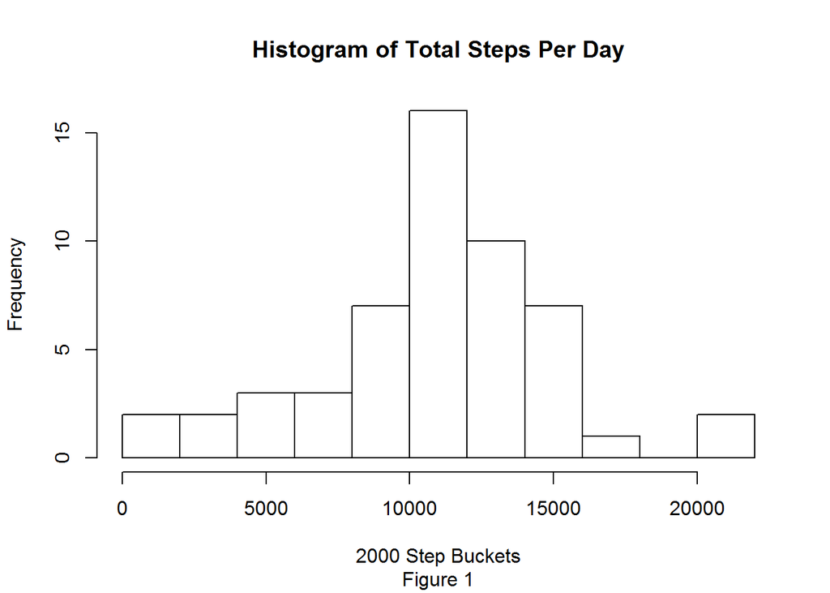

```r
  buckets <- c(0,2000,4000,6000,8000,10000,12000,14000,16000,18000,20000,22000)
  histOfStepsPerDay <- hist(stepsPerDay, main="Histogram of Total Steps Per Day", xlab="2000 Step Buckets", ylab ="Frequency", breaks=buckets, sub = "Figure 1")
```

For the sake of this exercise we are going to save all of our images to a subfolder called “figures”.

We will start by making sure that a figures folder exists in our current directory.

```r
  if(!dir.exists(".//figures")) {dir.create(".//figures")}
```

And then we will create a PNG of the graph.

```r
  png(filename = ".//figures//figure1.png")
  plot(histOfStepsPerDay)
  dev.off()
```

In addition to understanding the shape of this data, we should take a look at the mean and median of the data.

```r
  meanStepsPerDayExcludeNulls <- mean(stepsPerDay,na.rm = TRUE)
  meanStepsPerDayExcludeNulls
```

```
## [1] 10766.19
```

```r
  medianStepsPerDayExcludeNulls <- median(stepsPerDay,na.rm = TRUE)
  medianStepsPerDayExcludeNulls
```

```
## [1] 10765
```

### What is the average daily activity pattern?

Now that we have a solid understanding of what typical daily walking habits of this individual were, let’s take a look at how they walked throughout the day.

We are going to look at the mean number of steps they took durring the individual 5 minute intervals throughout the day.

```r
  meanStepsThroughoutDay <- tapply(nonNullActivityLog$steps, nonNullActivityLog$interval, mean)
  head(meanStepsThroughoutDay)
```

```
##         0         5        10        15        20        25
## 1.7169811 0.3396226 0.1320755 0.1509434 0.0754717 2.0943396
```

Now we are going to plot these averages to see how activity changes throughout the day.

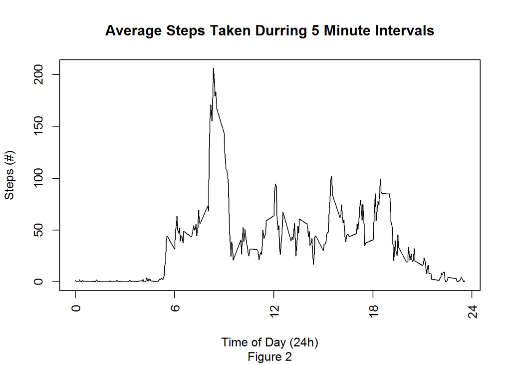

```r
  plot(strtoi(names(meanStepsThroughoutDay))/100,meanStepsThroughoutDay, type="l", main = "Average Steps Taken Durring 5 Minute Intervals", xlab="Time of Day (24h)",ylab="Steps (#)", xaxt="n", sub = "Figure 2")
  axis(1,at=seq(0,24, by=6),las=2)
```

Now we can save a copy of this image for future use.

```r
  png(filename = ".//figures//figure2.png")
  plot(strtoi(names(meanStepsThroughoutDay))/100,meanStepsThroughoutDay, type="l", main = "Average Steps Taken Durring 5 Minute Intervals", xlab="Time of Day (24h)",ylab="Steps (#)", xaxt="n", sub = "Figure 2")
  axis(1,at=seq(0,24, by=6),las=2)
  dev.off()
```

We can see that some time between 8 and 9 AM there is a spike in the average number of steps taken. In order to find out exactly what time this is we can sort all of times throughtout the day from highest average step count to lowest, and take the first value.

```r
  peakWalkingTime <- function(){
    maxMeanStepsThroughoutDay <- names(sort(meanStepsThroughoutDay, decreasing = TRUE)[1])
    textTime<-names(meanStepsThroughoutDay[meanStepsThroughoutDay = maxMeanStepsThroughoutDay])
    paste(substr(textTime, 1, nchar(textTime)-2), substr(textTime,nchar(textTime[1])-1,nchar(textTime[1])), sep = ":")
  }
```

This tells us that the highest average step count occurs at 8:35.

### Imputing missing values

Since there were missing values in the data we are going to perform some analysis about, and with placeholders for, the missing values.

We will start by looking for the total number of null values.

```r
  TotalNAs <- length(CompleteActivityLog$steps[is.na(CompleteActivityLog$steps)])
```

Which means that there are 2304 null records.

The most likely reason for these null records is that the person had taken off their tracking device. This could have happened for any number of reasons ranging from the subject taking a shower to wanting to look professional in a job interview. Since this is the simplistic reasoning that we are choosing to pursue, we are going to use the mean steps taken for that 5 minute interval (excluding the NAs) as a standin for the null values.

In order to do this we are going to use the following function to create a NullReplacedActivityLog dataset.

```r
  NullReplacement <- function(){
    meanStepsThroughoutDayDF <- data.frame(as.numeric(names(meanStepsThroughoutDay)), meanStepsThroughoutDay)
    names(meanStepsThroughoutDayDF) <- c("interval", "steps")
    NullReplacedActivityLog <- merge(CompleteActivityLog, meanStepsThroughoutDayDF, by="interval")
    NullReplacedActivityLog$steps.x <- with(NullReplacedActivityLog, ifelse(is.na(steps.x),steps.y,steps.x))
    NullReplacedActivityLog <- NullReplacedActivityLog[,c(2,3,1)]
    names(NullReplacedActivityLog) <- names(CompleteActivityLog)
    NullReplacedActivityLog
  }
  NullReplacedActivityLog <- NullReplacement()
  head(NullReplacedActivityLog)
```

```
##      steps       date interval
## 1 1.716981 2012-10-01        0
## 2 0.000000 2012-11-23        0
## 3 0.000000 2012-10-28        0
## 4 0.000000 2012-11-06        0
## 5 0.000000 2012-11-24        0
## 6 0.000000 2012-11-15        0
```

We can now create the same histogram that we did for the nonNullActivity dataset using this null replaced data.

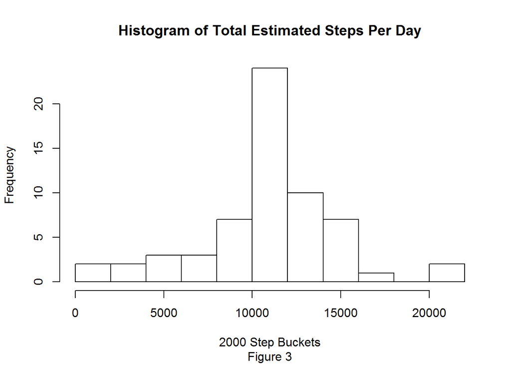

```r
    stepsPerDayEstimated <- tapply(NullReplacedActivityLog$steps, NullReplacedActivityLog$date, sum)
    histOfStepsPerDayEstimated <- hist(stepsPerDayEstimated, main="Histogram of Total Estimated Steps Per Day", xlab="2000 Step Buckets", ylab ="Frequency", breaks=buckets, sub = "Figure 3")
```

And to save this file.

```r
    png(filename = ".//figures//figure3.png")
    plot(histOfStepsPerDayEstimated)
    dev.off()
```

We can also see that the mean and median are:

```r
meanEstimatedStepsPerDayExcludeNulls <- mean(stepsPerDayEstimated,na.rm = TRUE)
  meanEstimatedStepsPerDayExcludeNulls
```

```
## [1] 10766.19
```

```r
  medianEstimatedStepsPerDayExcludeNulls <- median(stepsPerDayEstimated,na.rm = TRUE)
  medianEstimatedStepsPerDayExcludeNulls
```

```
## [1] 10766.19
```

As you can see, while the histogram maintains it’s general shape, you can see that there are several days that have been added to the 10,000 - 11,999 step bucket. As is expected, the mean did not change (this would actually indicate that there was a problem with the process mathematically). The median has increased slightly to match the mean because of the addition of the mean number of steps for each of the missing time intervals.  
### Are there differences in activity patterns between weekdays and weekends?

It is expected that people have different activity patterns on weekdays and weekends due to work and school.

We can take the dataset that we just created, to observe how the behavior changes between these two categories. What we will do is identify which days of the week each date indicates. Of those identify those that are weekend and weekday days respectively. Then set up a trellis plot to how the average trend throughout the day.

```r
  library(lattice)
  NullReplacedActivityLog$dayOfWeek <- weekdays(as.Date(NullReplacedActivityLog$date), abbreviate = TRUE)
  NullReplacedActivityLog$DayType <- as.factor(with(NullReplacedActivityLog, ifelse(dayOfWeek == "Sat" | dayOfWeek == "Sun", "Weekend","Weekday")))
  meanStepsThroughoutDayEstimated <- tapply(NullReplacedActivityLog$steps, list(NullReplacedActivityLog$interval, NullReplacedActivityLog$DayType), FUN = mean)
  weekdayMeanSteps <- data.frame(row.names(meanStepsThroughoutDayEstimated),meanStepsThroughoutDayEstimated[,1], rep("Weekday",length(meanStepsThroughoutDayEstimated[,1])))
  weekendMeanSteps <- data.frame(row.names(meanStepsThroughoutDayEstimated),meanStepsThroughoutDayEstimated[,2], rep("Weekend",length(meanStepsThroughoutDayEstimated[,2])))
  meanstepsThroughoutDayNames <- c("interval","steps","dayType")
  names(weekdayMeanSteps) <- meanstepsThroughoutDayNames
  names(weekendMeanSteps) <- meanstepsThroughoutDayNames
  meanStepsThroughoutDayEstimated <- rbind(weekdayMeanSteps, weekendMeanSteps)
  meanStepsThroughoutDayEstimated$interval <- as.numeric( as.character( meanStepsThroughoutDayEstimated$interval))
  weekdayVsWeekend <- xyplot(steps ~ interval/100 | dayType, meanStepsThroughoutDayEstimated, type = "l", layout=c(1,2), xlab = "Time Durring Day (24h)", ylab = "Mean Steps In 5 Minute Interval", main = "Average Steps Taken Throughout Day", sub = "Figure 4")
```

We can now create our final plot.

```r
  weekdayVsWeekend
```

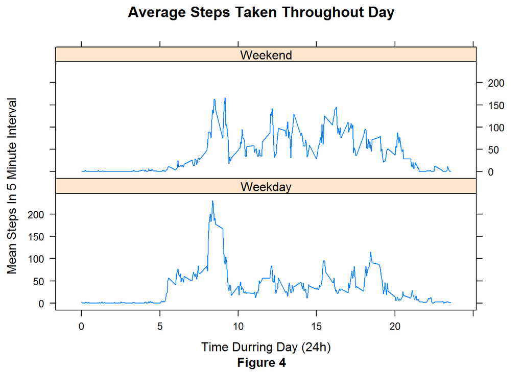

```r
  png(filename = ".//figures//figure4.png")
  weekdayVsWeekend
  dev.off()
```